| title: “G5999_Data Challenge 2” |
| --- |
| author: “Michael McCarthy” |
| date: “Mar 17, 2017” |
| output: html_document |

```r
rm(list=ls(all=TRUE))   # cleans everything in the workspace

library(readr)          # easier reading of flat files
library(caret)          # classification and regresssion training package
```

```r
library(randomForest)   # Random Forests package
library(ggplot2)
library(zoo)
library(dplyr)
require(plyr)
require(lubridate)
require(scales)
inFileName1   <- "../../data/processed/AllViolenceData_170216.csv"     # cleaned data on violence
AllData <- read_csv(inFileName1)
```

One question we wanted to investigate was whether any differences existed over time in the total number of deaths per confrontation.

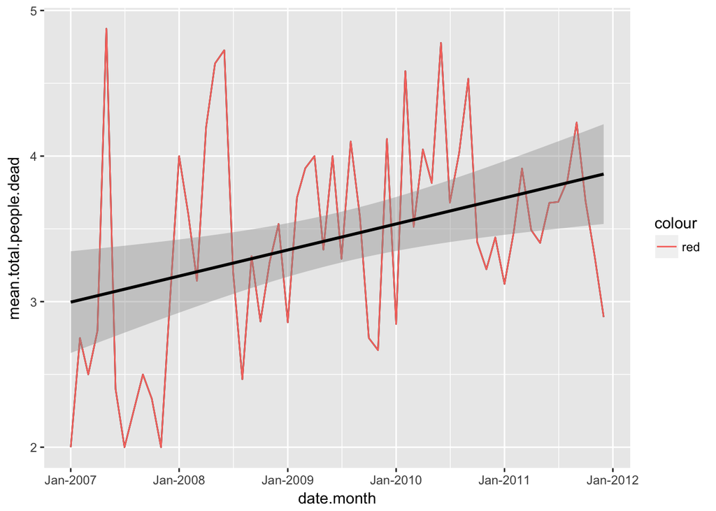

```r
AllData$date.month <- round_date(AllData$date, "month")
monthly_agg <- ddply(AllData[AllData$total.people.dead > 1,], .(date.month), summarize, mean.total.people.dead = mean(total.people.dead) )
ggplot(monthly_agg[2:nrow(monthly_agg),], aes(date.month, mean.total.people.dead)) +
  scale_x_date(labels=date_format("%b-%Y"), breaks=date_breaks("1 year")) +
  geom_line() +
  geom_line(aes(y=monthly_agg[2:nrow(monthly_agg),]$mean.total.people.dead, color="red")) +
  geom_smooth(method = "lm", se=TRUE, color="black", aes(group=1))
```

From the above chart we can see that there is a linear increasing trend in the number of deaths over time. However, there is quite a bit of fluctuation, even though we have smoothed out the trend by taking the average per month. The fluctuation month-to-month may be indication seasonality which would be interesting to explore in further analysis.

Finally, we built a linear model to predict the total number of people dead by month.

```r
summary(lm(total.people.dead ~ factor(date.month), data = AllData[AllData$total.people.dead > 0,]))
```

```
##
## Call:
## lm(formula = total.people.dead ~ factor(date.month), data = AllData[AllData$total.people.dead >
##     0, ])
##
## Residuals:
##    Min     1Q Median     3Q    Max
## -2.952 -1.320 -0.650  0.434 49.385
##
## Coefficients:
##                              Estimate Std. Error t value Pr(>|t|)
## (Intercept)                     7.000      2.544   2.751  0.00598 **
## factor(date.month)2007-01-01   -5.500      3.116  -1.765  0.07770 .
## factor(date.month)2007-02-01   -5.364      2.658  -2.018  0.04367 *
## factor(date.month)2007-03-01   -5.077      2.641  -1.923  0.05463 .
## factor(date.month)2007-04-01   -4.714      2.720  -1.733  0.08320 .
## factor(date.month)2007-05-01   -3.048      2.604  -1.170  0.24203
## factor(date.month)2007-06-01   -5.417      2.648  -2.045  0.04093 *
## factor(date.month)2007-07-01   -5.000      3.598  -1.389  0.16480
## factor(date.month)2007-08-01   -6.000      3.116  -1.925  0.05430 .
## factor(date.month)2007-09-01   -5.250      2.845  -1.845  0.06508 .
## factor(date.month)2007-10-01   -5.500      2.699  -2.038  0.04166 *
## factor(date.month)2007-11-01   -5.556      2.682  -2.071  0.03843 *
## factor(date.month)2007-12-01   -5.111      2.682  -1.906  0.05681 .
## factor(date.month)2008-01-01   -4.333      2.682  -1.616  0.10629
## factor(date.month)2008-02-01   -3.400      2.669  -1.274  0.20276
## factor(date.month)2008-03-01   -4.846      2.641  -1.835  0.06658 .
## factor(date.month)2008-04-01   -4.222      2.614  -1.615  0.10641
## factor(date.month)2008-05-01   -4.182      2.602  -1.607  0.10810
## factor(date.month)2008-06-01   -3.437      2.623  -1.311  0.19010
## factor(date.month)2008-07-01   -4.935      2.585  -1.909  0.05636 .
## factor(date.month)2008-08-01   -5.312      2.584  -2.056  0.03989 *
## factor(date.month)2008-09-01   -4.943      2.581  -1.915  0.05555 .
## factor(date.month)2008-10-01   -5.024      2.575  -1.951  0.05113 .
## factor(date.month)2008-11-01   -4.913      2.599  -1.890  0.05884 .
## factor(date.month)2008-12-01   -4.812      2.584  -1.862  0.06265 .
## factor(date.month)2009-01-01   -5.278      2.614  -2.019  0.04360 *
## factor(date.month)2009-02-01   -4.690      2.588  -1.812  0.07009 .
## factor(date.month)2009-03-01   -4.704      2.591  -1.815  0.06960 .
## factor(date.month)2009-04-01   -4.429      2.604  -1.700  0.08917 .
```

[output cut: 23 more lines]

```
## factor(date.month)2011-04-01   -4.744      2.555  -1.856  0.06352 .
## factor(date.month)2011-05-01   -4.731      2.556  -1.851  0.06429 .
## factor(date.month)2011-06-01   -4.611      2.556  -1.804  0.07137 .
## factor(date.month)2011-07-01   -4.645      2.556  -1.817  0.06933 .
## factor(date.month)2011-08-01   -4.350      2.557  -1.701  0.08903 .
## factor(date.month)2011-09-01   -4.385      2.557  -1.715  0.08647 .
## factor(date.month)2011-10-01   -4.186      2.559  -1.636  0.10203
## factor(date.month)2011-11-01   -5.100      2.557  -1.994  0.04621 *
## factor(date.month)2011-12-01   -5.163      2.574  -2.006  0.04498 *
## ---
## Signif. codes:  0 '***' 0.001 '**' 0.01 '*' 0.05 '.' 0.1 ' ' 1
##
## Residual standard error: 2.544 on 2610 degrees of freedom
## Multiple R-squared:  0.02465,    Adjusted R-squared:  0.002225
## F-statistic: 1.099 on 60 and 2610 DF,  p-value: 0.2815
```

In the output we can see that there are significant coefficients on the date.month, however the model overall is not significant since the F-statistic has a p-value of .2815. This indicates that time isn’t the only factor that can predict total deaths for fatal events, but it does appear that there are differences over time.